2025-10-02

## Your first week for LZSCC.461

1. **Today’s Lab** I will give:
   - An overview of whole module
   - I’ll tell how to set up R & RStudio
   - Intro to R
   - Intro to R Markdown
   - Reproducibility & writing coursework
2. **You** will go through Chapter 0 of the lecture [notes](https://modules.lancaster.ac.uk/mod/url/view.php?id=2677664)

Students that are not in LZSCC: this [link](https://rlsch.github.io/assets/html/LZSCC461/introduction-to-r.html).

## Overview

## Structure of the module

- Weeks 1-5: R programming
  - We’ll focus on the statistical side of programming
  - 2-hr Lecture, where I’ll give an overview of the week, do live coding and provide feedback about the past week.
  - 2-hr in-person lab each week
    - At the start of each lab, we will do a quiz to assess knowledge gained of the past week (not graded, don’t worry!)
    - Following that, you’ll go through the weekly notes and solve exercises
- Weeks 6-10: Python

## An overview of the R part

- Chapter 0: Intro to R (this slide deck)
- Chapter 1: Data manipulation and plotting
- Chapter 2: Manipulating time variables, Grouping and Summarising
- Chapter 3: Loops, if statements and simulation
- Chapter 4: Manipulating string variables
- [Chapter 5: Web scraping, interactive graphics, Shiny Apps (optional)]

## My contacts

- You can write me at **r.loesch@lancaster.ac.uk**
- Or message me on Teams

## Feedback and Assessment

- 25% R coursework
- 25% Python coursework
- 50% Final project, using both R and Python

## Set-up

## R \(\neq\) RStudio

R:

- The programming language
- The basic program for writing code in R

RStudio:

- Is an integrated development environment (IDE)
- Has many incredibly helpful features:
  - Shiny Apps
  - Creating your own R package
  - **R Markdown** files: compile to pdf, html, slides, etc.
  - Integration with e.g. Git and GitHub

## In a University computer lab

### (or on your laptop through AppsAnywhere)

- R and RStudio available through AppsAnywhere
- Point Microsoft Edge (works better in Edge than Chrome) at https://apps.lancaster.ac.uk/
- Select launch on: RStudio (includes R, RTools, Java, and most of the required packages for this module!)
- RStudio will be added to your list of programs on the Cloudpaging player and will (probably) launch
- (If it hasn’t launched automatically) You should be able to launch RStudio by double clicking on it in the Cloudpaging Player
- **Supported by IT services**

## On personal laptop, local installation

**NOTE: The university IT services nor I will be able to provide support with this. Use it at your own risk.**

1. Download R from CRAN: https://cran.r-project.org/ or https://www.r-project.org/
   - Official R repositories (even for packages!)
2. Download RStudio from https://www.rstudio.com/ (download free RStudio Desktop)
3. Alternatively, you can use RStudio Cloud from https://posit.cloud// (needs a free account)

## Intro to R (finally!)

## Today

- What is R
- Tips on coding
- Heads on Chapter 0
  - Basic calculations
  - Basic plots
  - Using functions
  - Creating R scripts

## What is R?

- R is a programming language and software environment for statistical computing and graphics
- It is widely used among statisticians and data scientistis
- Great for developing statistical software and data analysis
  - A wide variety of statistical and ML techniques
  - A comprehensive set of tools for data manipulation, calculation, and graphical representation.

## My advice on coding

- Programming is not a spectator sport
  - **Learn by doing**
- Annotating code
  - You write code for someone else, e.g. your future self
- DIE: Duplication Is Evil
  - Avoid repeated lines of code
  - Use functions - you will learn about writing them
- Human brains remember patterns, i.e. pick whatever coding style you like and stick to it

## My advice on coding

- Don’t have long horizontal lines of code, think vertically
  - RStudio gives you a guideline you should try to never cross!
- Break code into smaller sections rather than long paragraphs
- Name functions and variables carefully!
- Indent your code to make it more readable

## My advice on coding

- Style and readability do matter

[figure not shown]

## The internet (and coding)

- The Internet is (usually) your friend when you’re stuck!
  - R help files (e.g. *help(“lm”)* or *?lm* or ?"*“)
  - You can often search the solution
  - Online forums (e.g. https://stackoverflow.com)

## The internet (and coding)

- Be wary of generative models like ChatGPT. **Do not take their outputs for granted.**
- [University policy on Acknowledging AI in assessed work](https://portal.lancaster.ac.uk/ask/study/developing-academic-skills/using-ai-in-your-learning-and-assessment/)

[figure not shown]

## To help you learn/remember code

- There are a number of cheat sheets on the web
- RStudio cheat sheets: https://www.rstudio.com/resources/cheatsheets/
- I uploaded some of them in Moodle

## A typical R script file

```r
# Description of what I am doing
# Date

# Setup ----
# Load in required packages
library(tidyverse)

# Do some calculations
x <- 1234 + 4321
x ^ 2

# etc!
...
```

```r
3 + 5
```

```
## [1] 8
```

## Time to practice coding yourself

- Try to run R and RStudio
- Work through Chapter 0 of the notes
- Start with the exercises in the [notes](https://modules.lancaster.ac.uk/mod/url/view.php?id=2677664):
  - Section 0.3.5
  - Section 0.6.3
  - Section 0.7.4

## R Markdown & Reproducibility

## Reproducible research

- For every analysis your aim should be to have a script which reads in the raw data, prepares the variables, performs the analysis, produces the plots
- You should be able to rerun this from beginning to end without bugs
- This is so you can prove to others, and more importantly yourself, what you have done
- Ideally you should also have saved the output file (.Rout or knitr report) generated from your script file
- Do not just type commands in at the command prompt and copy the output

## The traditional workflow

1. Write code in an R script
2. Run code to get results i.e. numbers and plots
3. Copy the results to somewhere else e.g. MS Word or LaTeX
4. Insert the plots manually into the report
5. Figure something wrong, back to R script
6. Forget to save (some of) the updated results
7. The report contains some old and some new results
8. Others cannot reproduce your analysis

## The reproducible way

- Ideally, we have a “notebook” file that contains:
  - chunks of code
  - any accompanying text
- The document reporting the analysis is then generated dynamically, meaning that when the code/data changes, the results change accordingly
- This generated document contains the following interweaved:
  - the results i.e. numbers and plots
  - the accompanying text explaining these results
  - any code required

## The reproducible way

- This is the notebook approach:
  - In R, we will achieve this by R Markdown
  - In Python, there is the Jupyter notebook
- This is how you will write your coursework
  - Write everything in **one** R Markdown file
  - Generate a document in html
  - Submit the script file **and** the generated document
  - Easy to do in RStudio - instructions on following slides
- Testament: These slides are written by the same approach

## R Markdown notebooks

- In RStudio click: File | New File | R Notebook
- RStudio generates a basic R Markdown script file that looks like

```r
---
title: "R Notebook"
output: html_notebook
---
```

- This file has the extension `.Rmd`, not `.R`. This difference is significant as it means
  - you have to write R code in designated areas, but
  - you also can write normal text elsewhere.
- These slides where made with R Markdown!
- As a matter of fact, the whole lecture notes where made with R Markdown!
- Try following the instructions in this script file - I will demonstrate some of them

## R Markdown notebooks

- *We execute a chunk by clicking the *Run* button within the chunk or by placing your cursor inside it and pressing *Ctrl+Shift+Enter*.*

```{r}  
plot(cars)  
```

## R Markdown notebooks

This will print both the chunk, and the result:

```r
# I'm a programmer!
```

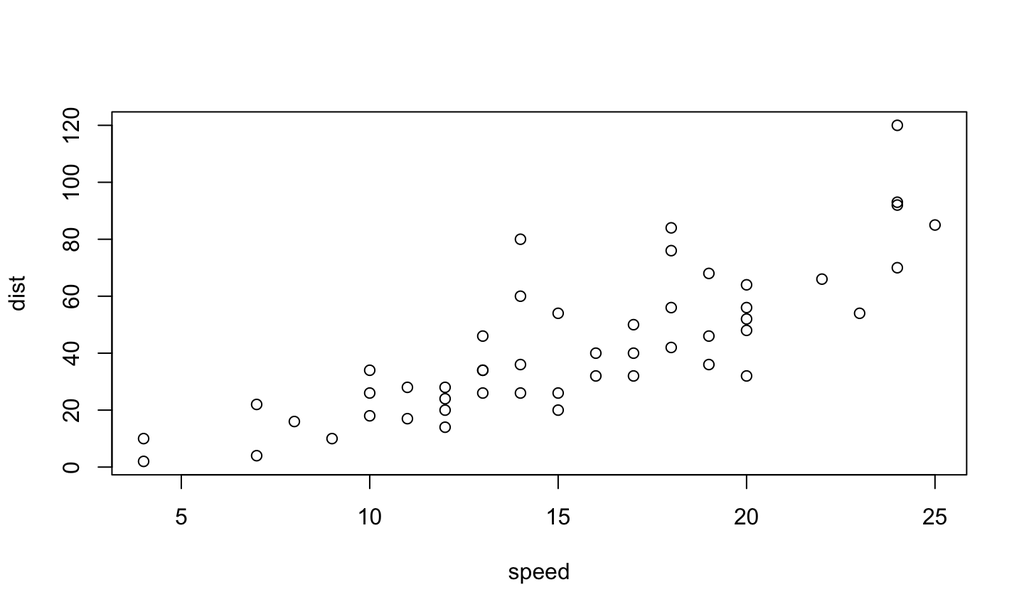

```r
plot(cars) # sdfgh
```

## R Markdown notebooks

- *We can add a new chunk by clicking the *Insert Chunk* button on the toolbar or by pressing *Ctrl+Alt+I*.*
- Type your R code for any analysis required within the chunk
- Execute this new chunk using the same steps as before

## R Markdown notebooks

- To generate the actual document, click the black arrow next to *Preview* (or *Knit* when you reopen the file)
- Choose *Knit to HTML* or *Knit to PDF*. The generated document will pop up **and** automatically saved in your working directory
- If you knit to PDF, you also need LaTeX installed on your system

## Writing coursework

1. Create a new markdown document
2. Edit the title, e.g. `title: R Coursework 0`
3. Add an author, e.g. `author: Student ID #####`
4. `output: html_document`
5. Save file (File | Save) with .Rmd extension
6. Remove the example text and code chunks!

## Writing coursework (cont’d)

1. Repeat the following for each part/question:
   - Put your R code in a new chunk, i.e. between ```{r} and ```
   - Click the green triangle to run the individual chunk **or** black arrow next to *Run* button to run multiple chunks
   - Check if the results are correct/make sense
   - Add text to explain your results if necessary
2. Click black arrow next to *Knit* button and generate an HTML or PDF
   - If you have specified output: …_document click *Knit* button to compile your document directly

## Summary & final remarks

- We have learned how to:
  - Do R coding in RStudio
  - Generate simple yet reproducible document
- These will go a long way in this course
- The format of coursework varies, but the workflow and submission are the same
- It might not be a gentle learning curve, but
  - this is the industrial standard
  - things will get easier later on this year
- Spend some time on the notes & these slides